# **Financial Contribution for 2016 Election (Illinois)**

# **Abstract**

Who received the most contributions? Are candidates who got more contributions more likely to get more votes? How are contributors distributed geographically? Are there any patterns for different candidates? What are the profiles of contributors for different candidates/parties?

This report explores the data of financial contributions in Illinois for the 2016 Election in hope to find answers to these questions.

# **Dataset**

## **Preparations**

Importing Data and examine what is contained in there.

```r
FC <- read.csv('P00000001-IL.csv')
str(FC)
```

```
## 'data.frame':    250411 obs. of  19 variables:
##  $ X                : int  1 2 3 4 5 6 7 8 9 10 ...
##  $ cmte_id          : Factor w/ 24 levels "C00458844","C00500587",..: 6 15 7 15 7 7 7 6 6 6 ...
##  $ cand_id          : Factor w/ 24 levels "P00003392","P20002671",..: 1 23 12 23 12 12 12 1 1 1 ...
##  $ cand_nm          : Factor w/ 24 levels "Bush, Jeb","Carson, Benjamin S.",..: 4 22 19 22 19 19 19 4 4 4 ...
##  $ contbr_nm        : Factor w/ 52686 levels "'CALLAHAN, CHRIS",..: 15057 38033 27566 36136 28537 22091 22091 11408 3585 18652 ...
##  $ contbr_city      : Factor w/ 1521 levels "0LMSTED","25 F CHICAGO",..: 715 617 243 243 1081 243 243 201 1489 1007 ...
##  $ contbr_st        : Factor w/ 1 level "IL": 1 1 1 1 1 1 1 1 1 1 ...
##  $ contbr_zip       : int  601564641 60192 606223057 60622 615542542 606576225 606576225 622311258 600911971 619430433 ...
##  $ contbr_employer  : Factor w/ 17536 levels "","-","--","(NONE)",..: 13786 13839 17462 7625 6922 11229 11229 7625 10075 10695 ...
##  $ contbr_occupation: Factor w/ 8363 levels "","-","--"," CERTIFIED REGISTERED NURSE ANESTHETIS",..: 6565 1220 8239 3643 6129 4888 4888 3643 6536 6338 ...
##  $ contb_receipt_amt: num  33.5 400 50 601.6 15 ...
##  $ contb_receipt_dt : Factor w/ 682 levels "1-Apr-15","1-Apr-16",..: 176 235 609 390 587 609 609 421 44 2 ...
##  $ receipt_desc     : Factor w/ 32 levels "","* EARMARKED CONTRIBUTION: SEE BELOW REATTRIBUTION/REFUND PENDING",..: 1 1 1 1 1 1 1 1 1 1 ...
##  $ memo_cd          : Factor w/ 2 levels "","X": 2 2 1 2 1 1 1 2 2 2 ...
##  $ memo_text        : Factor w/ 126 levels "","$0.04 REFUNDED ON 10/25/2016",..: 23 1 18 1 18 18 18 23 23 23 ...
##  $ form_tp          : Factor w/ 3 levels "SA17A","SA18",..: 2 2 1 2 1 1 1 2 2 2 ...
##  $ file_num         : int  1091718 1146165 1077404 1146165 1077404 1077404 1077404 1091718 1091718 1091718 ...
##  $ tran_id          : Factor w/ 249967 levels "A0026BD64F7D64A08896",..: 85172 172660 201960 172648 201573 201985 202122 85468 85069 84821 ...
##  $ election_tp      : Factor w/ 5 levels "","G2016","O2016",..: 4 2 4 2 4 4 4 4 4 4 ...
```

Remove duplicate/irrelevant columns:  
+ cmte_id,cand_id: duplicate data with candidate names  
+ tran_id: not relevant for our analysis  
+ contbr_st: the dataset is for Illinois  
+ memo_text: out of scope of analysis  
+ memo_cd: same as above  
+ file_num: not relevant for our analysis  
+ form_tp: not useful for our analysis  
+ receipt_desc: not useful for our analysis

```r
FC <- subset(FC, select = -c(cmte_id,cand_id,tran_id,contbr_st,
                             memo_text,memo_cd,file_num,form_tp,receipt_desc))
FC <- rename(FC, c('cand_nm'           = 'Candidate_name',
                   'contbr_nm'         = 'Contr_Name',
                   'contbr_city'       = 'Contr_City',
                   'contbr_zip'        = 'Contr_zip',
                   'contbr_employer'   = 'Contr_employer',
                   'contbr_occupation' = 'Contr_occupation',
                   'contb_receipt_amt' = 'Contr_amount',
                   'contb_receipt_dt'  = 'Contr_date'))
FC$Contr_zip <- factor(FC$Contr_zip)

str(FC)
```

```
## 'data.frame':    250411 obs. of  10 variables:
##  $ X               : int  1 2 3 4 5 6 7 8 9 10 ...
##  $ Candidate_name  : Factor w/ 24 levels "Bush, Jeb","Carson, Benjamin S.",..: 4 22 19 22 19 19 19 4 4 4 ...
##  $ Contr_Name      : Factor w/ 52686 levels "'CALLAHAN, CHRIS",..: 15057 38033 27566 36136 28537 22091 22091 11408 3585 18652 ...
##  $ Contr_City      : Factor w/ 1521 levels "0LMSTED","25 F CHICAGO",..: 715 617 243 243 1081 243 243 201 1489 1007 ...
##  $ Contr_zip       : Factor w/ 30617 levels "0","97","99",..: 8002 176 19253 341 26257 23501 23501 28706 5885 28008 ...
##  $ Contr_employer  : Factor w/ 17536 levels "","-","--","(NONE)",..: 13786 13839 17462 7625 6922 11229 11229 7625 10075 10695 ...
##  $ Contr_occupation: Factor w/ 8363 levels "","-","--"," CERTIFIED REGISTERED NURSE ANESTHETIS",..: 6565 1220 8239 3643 6129 4888 4888 3643 6536 6338 ...
##  $ Contr_amount    : num  33.5 400 50 601.6 15 ...
##  $ Contr_date      : Factor w/ 682 levels "1-Apr-15","1-Apr-16",..: 176 235 609 390 587 609 609 421 44 2 ...
##  $ election_tp     : Factor w/ 5 levels "","G2016","O2016",..: 4 2 4 2 4 4 4 4 4 4 ...
```

Taking a look at the contribution amount overall:

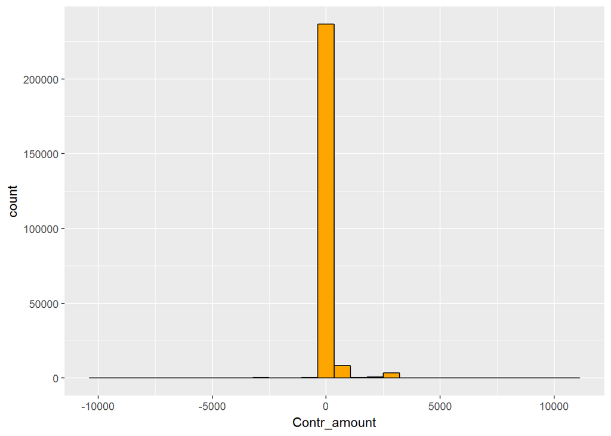

```r
ggplot(data = FC, aes(x = Contr_amount)) +
  geom_histogram(color = 'black', fill = 'orange')
```

This plot does not show much.

Let’s try applying a log10 scale for the amount:

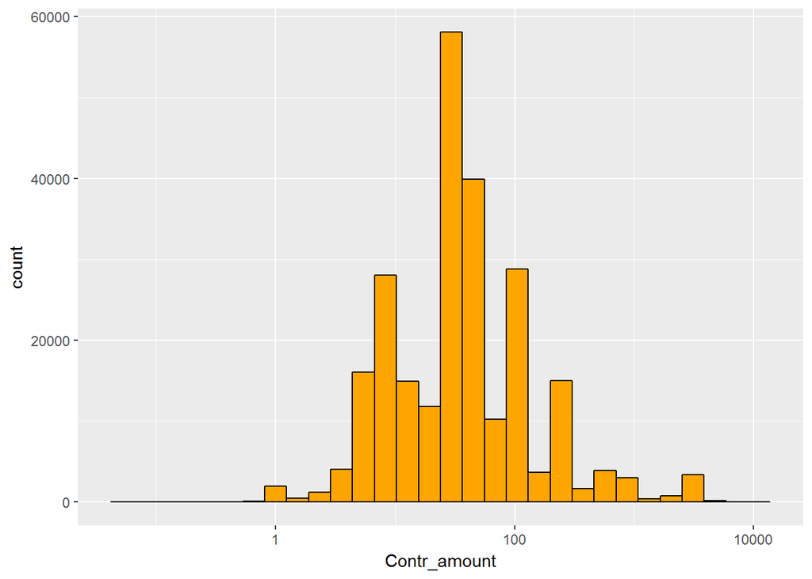

```r
ggplot(data = FC, aes(x = Contr_amount)) +
  geom_histogram(color = 'black', fill = 'orange') +
  scale_x_log10()
```

Taking a look at boxplot:

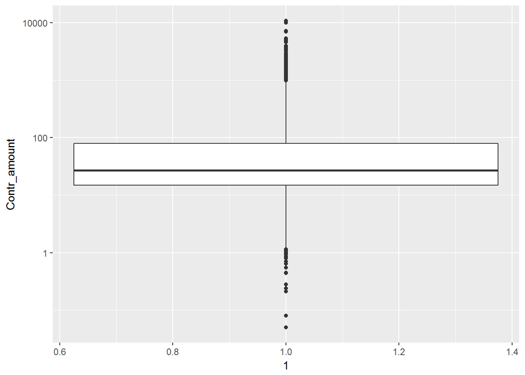

```r
ggplot(data = FC, aes(x = 1, y = Contr_amount)) +
  geom_boxplot() +
  scale_y_log10()
```

Most donations are under 100.

Let’s take a look at a summary table for different candidates:

```r
#Group by each candidate, summarise mean, median, sum and total number of contributions, then filter out those with less than half a million in donation.
FC_updated <- FC %>% group_by(Candidate_name) %>%
  summarise(sum_amount = sum(Contr_amount),
            median_amount = median(Contr_amount),
            mean_amount = mean(Contr_amount),
            max_amount = max(Contr_amount),
            n = n()) %>%
  arrange(desc(sum_amount))

#resetting factors
FC_updated$Candidate_name <- factor(FC_updated$Candidate_name)

#resulting table is as below
FC_updated
```

```
## # A tibble: 24 x 6
##               Candidate_name sum_amount median_amount mean_amount
##                       <fctr>      <dbl>         <dbl>       <dbl>
##  1   Clinton, Hillary Rodham 16152026.8         25.00   131.70921
##  2          Trump, Donald J.  3490011.1         55.13   149.35641
##  3          Sanders, Bernard  3295108.3         27.00    43.07218
##  4 Cruz, Rafael Edward 'Ted'  1241112.7         50.00    92.85596
##  5              Rubio, Marco   964158.9        100.00   322.78505
##  6                 Bush, Jeb   640064.0        300.00  1014.36450
##  7       Carson, Benjamin S.   638877.6         50.00   106.78215
##  8           Kasich, John R.   539898.2        250.00   516.64904
##  9             Walker, Scott   355916.0        250.00   711.83200
## 10                Paul, Rand   196795.2         50.00   168.05735
## # ... with 14 more rows, and 2 more variables: max_amount <dbl>, n <int>
```

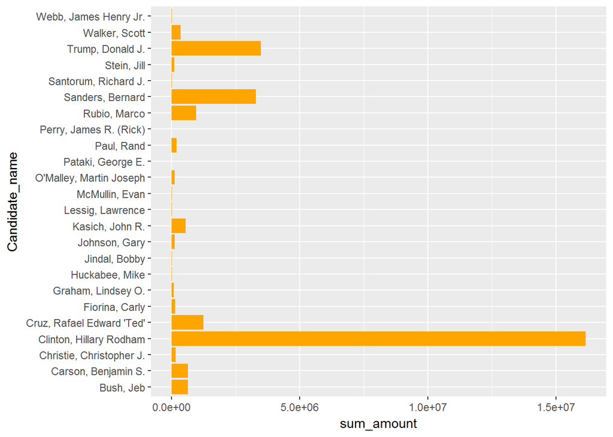

```r
ggplot(data = FC_updated, aes(Candidate_name, sum_amount)) +
  geom_col(fill = 'orange') +
  coord_flip()
```

Taking a look at the boxplot:

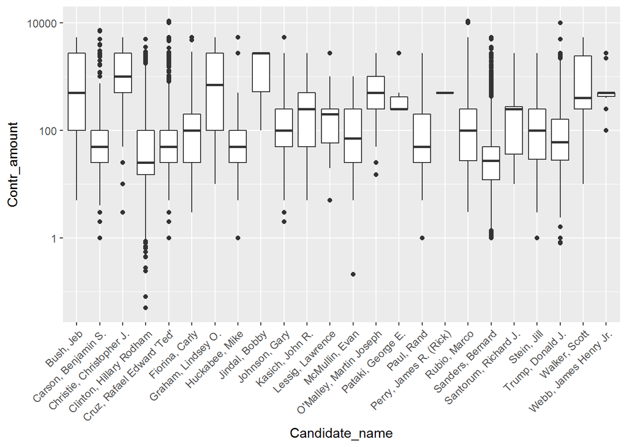

```r
ggplot(data = FC, aes(y = Contr_amount, x = Candidate_name)) +
  geom_boxplot() +
  scale_y_log10() +
  theme(axis.text.x = element_text(angle = 45, hjust = 1))
```

Keeping only candidates who have more than half a million in contributions. This would make subsequent analysis by candidates easier.

```r
#Group by each candidate, summarise mean, median, sum and total number of contributions, then filter out those with less than half a million in donation.
FC_selected <-  subset(FC_updated, sum_amount > 500000)

#resetting factors
FC_selected$Candidate_name <- factor(FC_selected$Candidate_name)

#resulting table is as below
FC_selected
```

```
## # A tibble: 8 x 6
##              Candidate_name sum_amount median_amount mean_amount
##                      <fctr>      <dbl>         <dbl>       <dbl>
## 1   Clinton, Hillary Rodham 16152026.8         25.00   131.70921
## 2          Trump, Donald J.  3490011.1         55.13   149.35641
## 3          Sanders, Bernard  3295108.3         27.00    43.07218
## 4 Cruz, Rafael Edward 'Ted'  1241112.7         50.00    92.85596
## 5              Rubio, Marco   964158.9        100.00   322.78505
## 6                 Bush, Jeb   640064.0        300.00  1014.36450
## 7       Carson, Benjamin S.   638877.6         50.00   106.78215
## 8           Kasich, John R.   539898.2        250.00   516.64904
## # ... with 2 more variables: max_amount <dbl>, n <int>
```

Remove observations of removed candidates from the main dataframe and create a copy:

```r
#keeping a copy of original dataset
FC_copy <- FC

FC <- subset(FC, (FC$Candidate_name %in%
                    levels(FC_selected$Candidate_name)))
FC <- subset(FC, FC$Contr_amount > 0)

levels(FC_selected$Candidate_name)
```

```
## [1] "Bush, Jeb"                 "Carson, Benjamin S."
## [3] "Clinton, Hillary Rodham"   "Cruz, Rafael Edward 'Ted'"
## [5] "Kasich, John R."           "Rubio, Marco"
## [7] "Sanders, Bernard"          "Trump, Donald J."
```

#### **Total contributions by candidates**

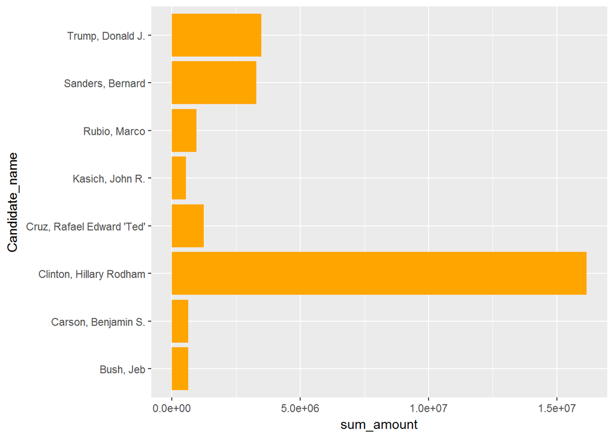

Create Factor Variable: Democrat, Republican, Third Parties and Independents and add to existing main dataframe:

```r
#manually create dataframe that assigns political party to each candidate
Candidates <- levels(FC_selected$Candidate_name)
Candidate_Party <- c('Republican', 'Republican','Democratic','Republican',
                     'Republican','Republican','Democratic','Republican')
df_CP <- data.frame(Candidates,Candidate_Party)

#matching df_CP to the main dataframe
FC$Party <- df_CP$Candidate_Party[match(FC$Candidate_name, df_CP$Candidates)]
```

#### **Plotting amount histogram by parties**

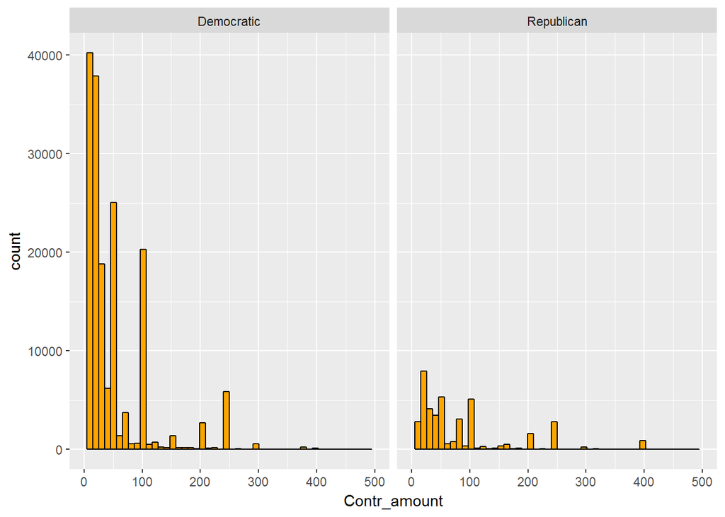

```r
ggplot(data = FC, aes(x = Contr_amount)) +
  geom_histogram(color = 'black', fill = 'orange', bins = 50) +
  xlim(0, 500) +
  facet_wrap(~Party, ncol = 2)
```

Not surprisingly, most people donated below $100 as the density seems much higher on the left side of the plots. Again, we take the logarithmic value of the contributions to address this and turn the distribution into something that more closely resemble normal distributions. Applying a layer of color for different candidates just for fun.

### **Log Scale Histogram for Contributions**

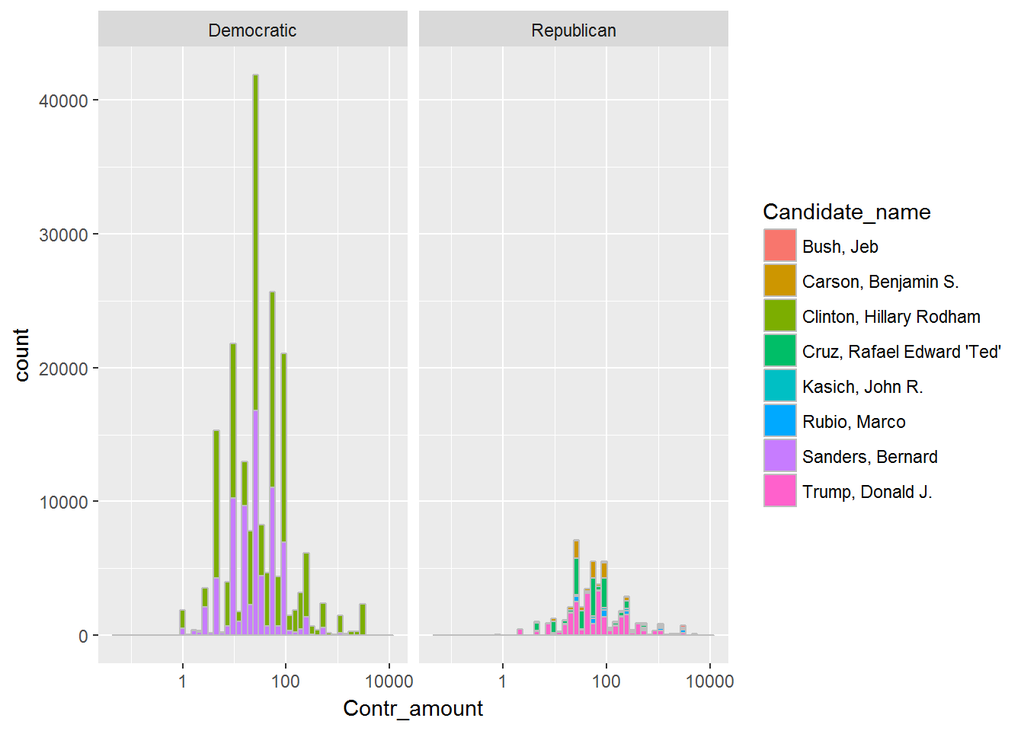

```r
ggplot(data = FC, aes(x = Contr_amount, fill = Candidate_name)) +
  geom_histogram(color = 'gray', bins = 50)  +
  facet_wrap(~Party, ncol = 2) +
  scale_x_log10()
```

The plots indeed seem closer to a normal distribution. The plots match summary. Clinton received the most contributions by far, more than 4x the second highest.

Let’s look at the boxplot of contributions for each candidate

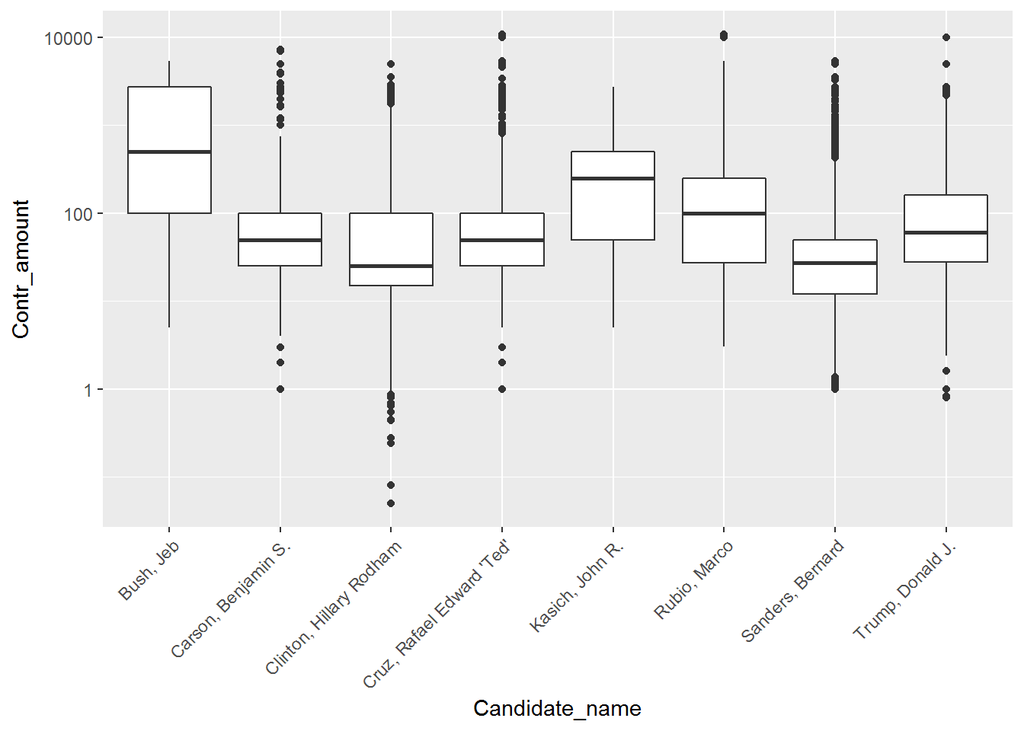

```r
ggplot(data = FC, aes(y = Contr_amount, x = Candidate_name)) +
  geom_boxplot() +
  scale_y_log10() +
  theme(axis.text.x = element_text(angle = 45, hjust = 1))
```

#### **Plotting contribution histogram individually for each candidate**

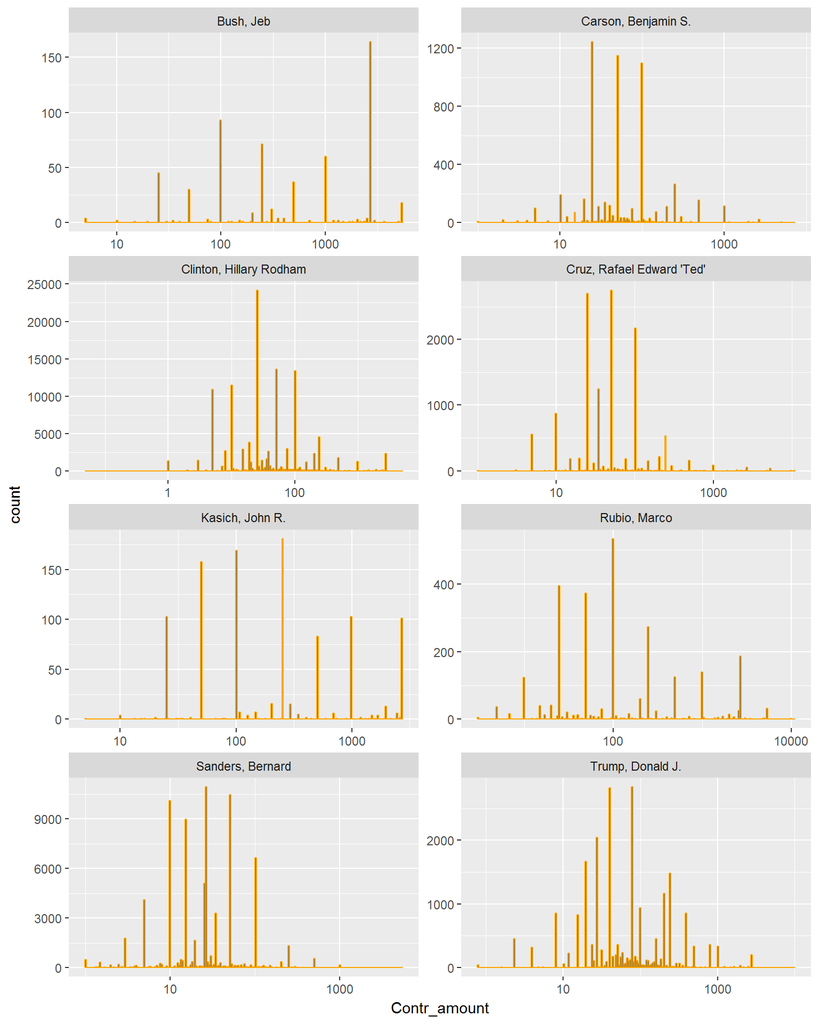

```r
ggplot(data = FC, aes(x = Contr_amount)) +
  geom_histogram(color = 'orange', bins = 200)  +
  facet_wrap(~Candidate_name, scales = 'free',ncol=2) +
  scale_x_log10()
```

Following the example from the course instruction. I wanted to create maps showing contributions. Unlike the example, I was not given longtitude and latitude in the dataset. However, the dataset does contain the postal codes. I researched on Google and found a way to turn zipcodes into geographical coordinates using the library, with the help from the link below: [link](https://austinwehrwein.com/digital-humanities/creating-a-density-map-in-r-with-zipcodes/)

Below are the steps I took to clean up the zipcodes and match them with according longtitudes and latitudes.

```r
#cleaning up zipcodes
data("zipcode")
FC$Contr_zip <- clean.zipcodes(FC$Contr_zip)

#keeping only the first 5 digits of zipcode to be matched with zipcode library
FC$Contr_zip <- substr(FC$Contr_zip, 0, 5)

#matching zipcode onto dataframe
FC$lat <- zipcode$latitude[match(FC$Contr_zip, zipcode$zip)]
FC$lng <- zipcode$longitude[match(FC$Contr_zip, zipcode$zip)]

#now the new dataframe looks like this:
head(FC)
```

```
##   X          Candidate_name        Contr_Name        Contr_City Contr_zip
## 1 1 Clinton, Hillary Rodham    FUCHS, LEE ANN LAKE IN THE HILLS     60156
## 2 2        Trump, Donald J.  PUSATERI, THOMAS   HOFFMAN ESTATES     60192
## 3 3        Sanders, Bernard   LIEBIG, BRANDON           CHICAGO     60622
## 4 4        Trump, Donald J. PAVLJASEVIC, MARK           CHICAGO     60622
## 5 5        Sanders, Bernard   LYBARGER, ANGEL             PEKIN     61554
## 6 6        Sanders, Bernard   JAKABHAZY, LYRA           CHICAGO     60657
##              Contr_employer      Contr_occupation Contr_amount Contr_date
## 1     SEARS, ROEBUCK AND CO         SALES MANAGER        33.55  17-Apr-16
## 2             SELF-EMPLOYED          CHIROPRACTOR       400.00  19-Nov-16
## 3 ZACKS INVESTMENT RESEARCH          WEB DESIGNER        50.00   6-Mar-16
## 4     INFORMATION REQUESTED INFORMATION REQUESTED       601.61  25-Nov-16
## 5          HEYDE EYE CENTER          RECEPTIONIST        15.00   5-Mar-16
## 6              NOT EMPLOYED          NOT EMPLOYED         5.00   6-Mar-16
##   election_tp      Party      lat       lng
## 1       P2016 Democratic 42.18573 -88.34848
## 2       G2016 Republican 42.06583 -88.21399
## 3       P2016 Democratic 41.90033 -87.66927
## 4       G2016 Republican 41.90033 -87.66927
## 5       P2016 Democratic 40.56709 -89.63382
## 6       P2016 Democratic 41.94083 -87.65852
```

#### **Plotting contributor map by candidates**

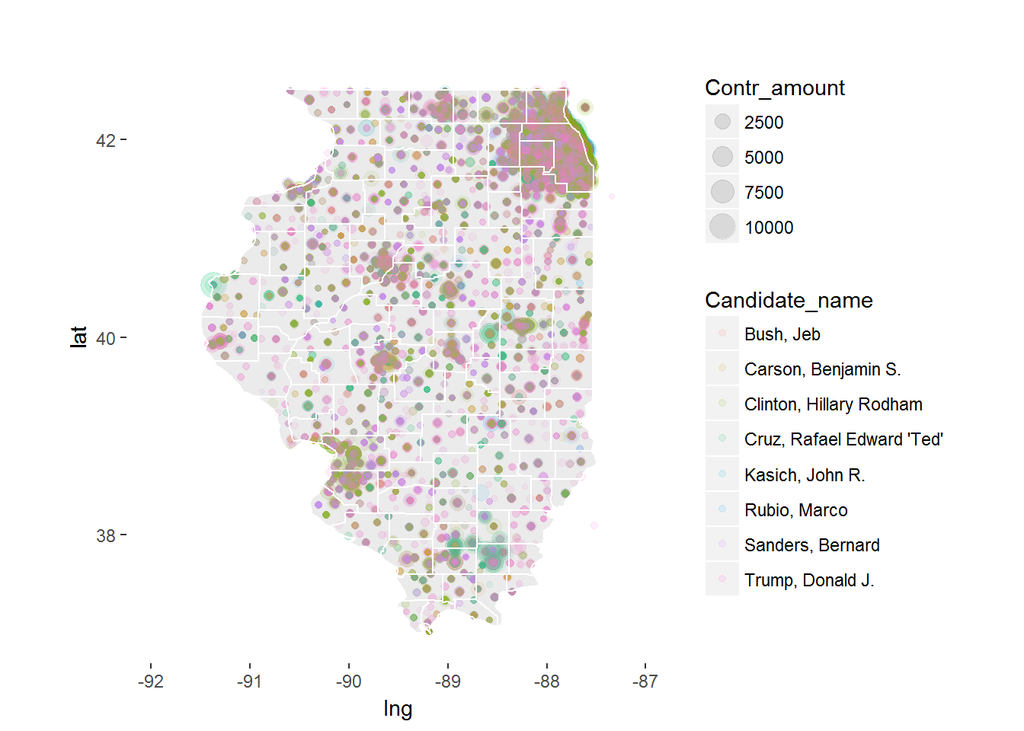

```r
us <- map_data('state')
illinois <- subset(us, region == 'illinois')
counties <- map_data("county")
il_county <- subset(counties, region == 'illinois')
ggplot(aes(x = lng, y = lat, color = Candidate_name,
           size = Contr_amount), data = FC) +
  geom_point(alpha = 0.1) +
  geom_polygon(data = illinois, aes(x = long, y = lat, group = group),
               color = 'gray', fill = 'gray', alpha = 0.3, inherit.aes = FALSE) +
  xlim(-92, -87) +
  ylim(37, 43) +
  coord_fixed(1) +
  geom_polygon(data = il_county, aes(x = long, y = lat, group = group),
                fill = NA, color = "white", inherit.aes = FALSE) +
  theme(panel.grid = element_blank(), panel.background = element_blank())
```

From the plot, we cannot really tell size from density. The colors don’t work very well because there are too many colors on a very densed map.

Let’s try plotting contributions on map, colored by political leanings.

#### **Plotting contributor map by parties**

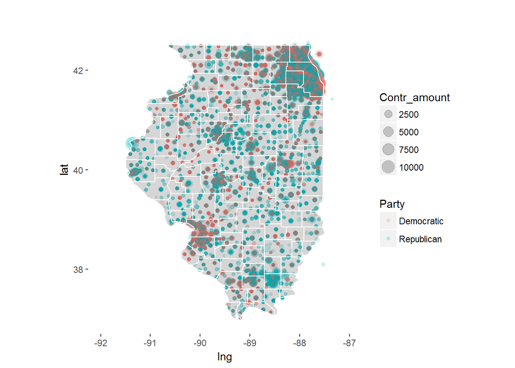

```r
ggplot(aes(x = lng, y = lat, color = Party,
           size = Contr_amount), data = FC) +
  geom_point(alpha = 0.2) +
  geom_polygon(data = illinois, aes(x = long, y = lat, group = group),
               color = 'gray', alpha = 0.2, inherit.aes = FALSE) +
  xlim(-92, -87) +
  ylim(37, 43) +
  coord_fixed(1) +
  geom_polygon(data = il_county, aes(x = long, y = lat, group = group),
                fill = NA, color = "white", inherit.aes = FALSE) +
  theme(panel.grid = element_blank(), panel.background = element_blank())
```

This is very interesting. Even though democratic party received most of the contributions, the map is pretty overwhelmed by the blue that represents republican. Looking at the data of the dataframe, there are only 50k contributor for more than 250k contributions. People can donate different amounts but each person only get one vote. It might be interesting to look into the data of unique contributors - this is definitely closer to the vote counts that they are likely to get.

```r
unique_contr <- FC %>%
  group_by(Candidate_name) %>%
  summarise(unique_contributors = n_distinct(Contr_Name)) %>%
  arrange(desc(unique_contributors))

unique_contr
```

```
## # A tibble: 8 x 2
##              Candidate_name unique_contributors
##                      <fctr>               <int>
## 1   Clinton, Hillary Rodham               19756
## 2          Trump, Donald J.               17171
## 3          Sanders, Bernard                9425
## 4 Cruz, Rafael Edward 'Ted'                2623
## 5       Carson, Benjamin S.                1583
## 6              Rubio, Marco                1023
## 7           Kasich, John R.                 602
## 8                 Bush, Jeb                 393
```

#### **Plotting unique contributor by candidate:**

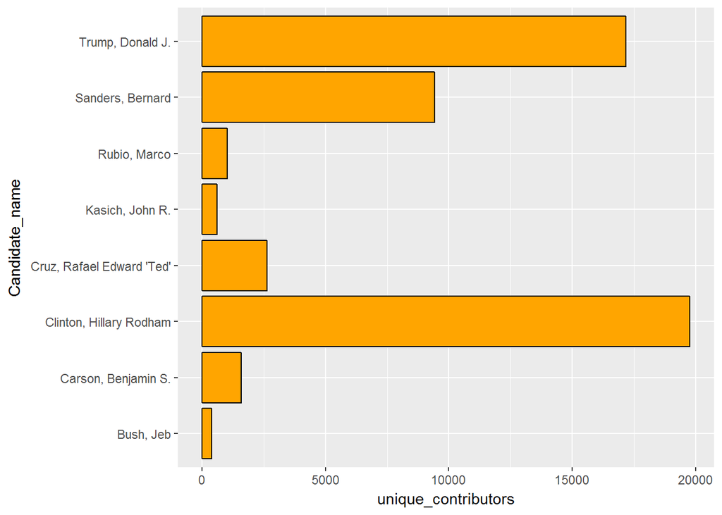

```r
ggplot(unique_contr, aes(Candidate_name, unique_contributors)) +
  geom_col(color = 'black', fill = 'orange') +
  coord_flip()
```

We can see that Trump and Clinton are actually pretty close in the numbers of unique contributors - this was far from clear if we only look at the total amount or total number of contributions for each.

Let’s put the plot of total contribution by candidates and the plot of unique contributor by candidate side by side.

#### **Plots Total Contributions vs Number of Unique Contributors**

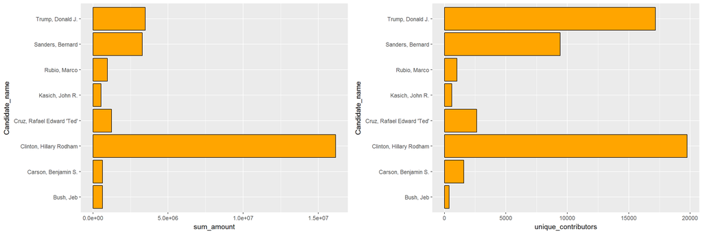

```r
f1 = ggplot(data = FC_selected, aes(Candidate_name, sum_amount)) +
  geom_col(fill = 'orange', color = 'black') +
  coord_flip()
f2 = ggplot(unique_contr, aes(Candidate_name, unique_contributors)) +
  geom_col(color = 'black', fill = 'orange') +
  coord_flip()

grid.arrange(f1, f2, ncol = 2)
```

Checking the number of unique contributors by parties:

```r
unique_contr_party <- FC %>%
  group_by(Party) %>%
  summarise(unique_contributors = n_distinct(Contr_Name)) %>%
  arrange(desc(unique_contributors))

unique_contr_party
```

```
## # A tibble: 2 x 2
##        Party unique_contributors
##       <fctr>               <int>
## 1 Democratic               28743
## 2 Republican               22754
```

I want to get a sense of who have donated more than once.

```r
top_contributors <- FC %>%
  group_by(Contr_Name) %>%
  summarise(mean = mean(Contr_amount),
            n=n()) %>%
  arrange(desc(n))


top_contributors$party <-
  FC$Party[match(top_contributors$Contr_Name, FC$Contr_Name)]
top_contributors$candidate <-
  FC$Candidate_name[match(top_contributors$Contr_Name, FC$Contr_Name)]
head(top_contributors, 20)
```

```
## # A tibble: 20 x 5
##             Contr_Name      mean     n      party               candidate
##                 <fctr>     <dbl> <int>     <fctr>                  <fctr>
##  1      PURCELL, LARRY  4.450355   705 Democratic        Sanders, Bernard
##  2  KELJIK, PATRICIA A  4.046464   345 Democratic        Sanders, Bernard
##  3   MACMAHON, PATRICK  9.608545   220 Democratic Clinton, Hillary Rodham
##  4    VARILLA, JEFFREY  8.599691   194 Democratic        Sanders, Bernard
##  5      SMITH, GREGORY 11.769231   182 Democratic Clinton, Hillary Rodham
##  6       JEFFERY, MARK 16.263500   180 Democratic Clinton, Hillary Rodham
##  7   BARLOW, PRISCILLA 27.095251   179 Democratic Clinton, Hillary Rodham
##  8    WOODING, JOHN D. 13.135838   173 Democratic        Sanders, Bernard
##  9 PAPIERNIAK, CYNTHIA  7.266337   172 Democratic Clinton, Hillary Rodham
## 10         M., KRISTIN  4.653711   159 Democratic        Sanders, Bernard
## 11        PIERCE, JANE 13.608947   152 Democratic Clinton, Hillary Rodham
## 12      HOLLIS, MARSHA 22.377483   151 Democratic Clinton, Hillary Rodham
## 13     BARTON, BRANDON 10.866259   147 Democratic Clinton, Hillary Rodham
## 14        KWAK, BOGDAN 11.510432   139 Democratic        Sanders, Bernard
## 15      LLOYD, MICHAEL 14.978978   137 Democratic Clinton, Hillary Rodham
## 16      PEZZINO, SUSAN 19.627481   135 Democratic        Sanders, Bernard
## 17      BARTLEY, CAROL  6.160902   133 Democratic Clinton, Hillary Rodham
## 18       KELLY, EILEEN 39.235191   131 Democratic Clinton, Hillary Rodham
## 19   THODOS, CHRISTINA 10.706031   131 Democratic        Sanders, Bernard
## 20    BARBER, PATRICIA 43.384186   129 Democratic Clinton, Hillary Rodham
```

It looks like they are mostly democratic contributors. In fact, there are only one republican in the top 50 contributor by the times they have donated.

Let’s try plotting this:

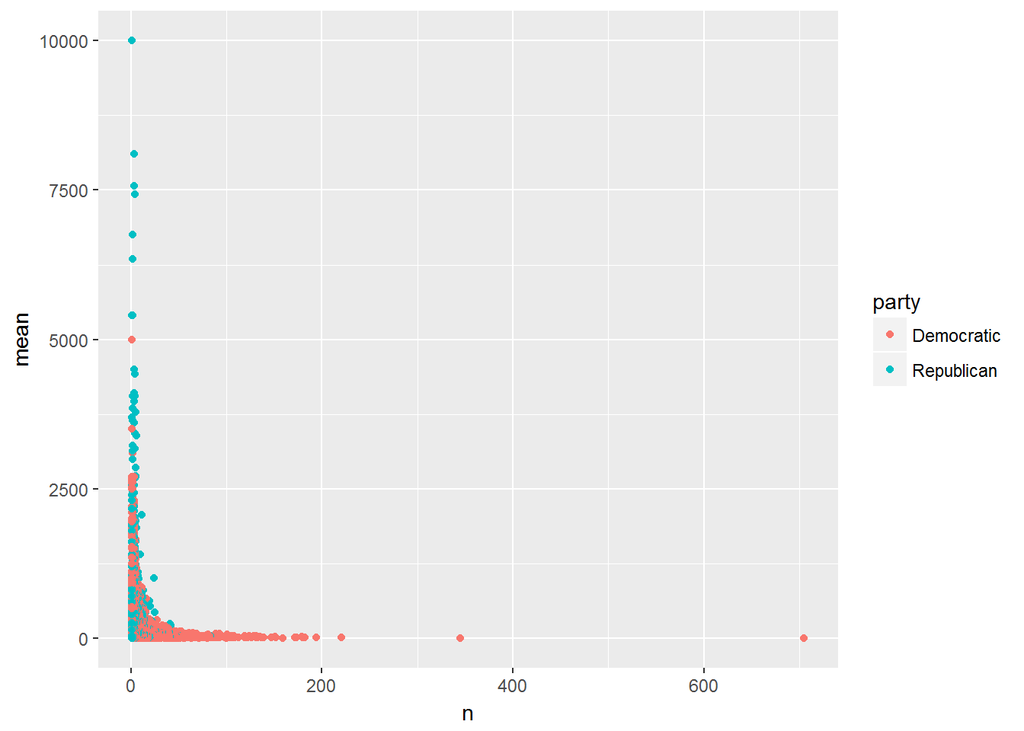

```r
ggplot(aes(x = n, y = mean, color = party),
       data = top_contributors) +
  geom_point()
```

There is definitely a pattern between democratic and republican contributors. Let’s try log scale.

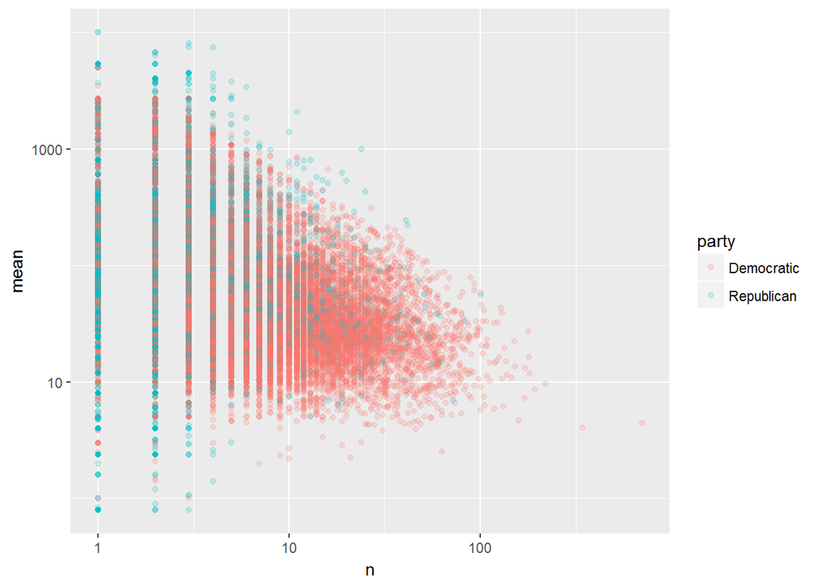

```r
ggplot(aes(x = n, y = mean, color = party), data = top_contributors) +
  geom_point(alpha = 0.2) +
  scale_x_log10() +
  scale_y_log10()
```

Very interesting. Significantly more democrats contributed many times. Those who donated highest amounts are mostly republicans.

#### **Contribution Map by Candidate**

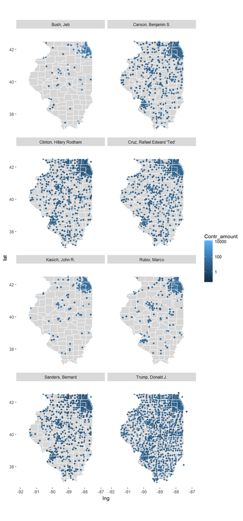

```r
ggplot(aes(x = lng, y = lat, color = Contr_amount), data = FC) +
  geom_point() +
  geom_polygon(data = illinois, aes(x = long, y = lat, group = group),
               color = 'gray', alpha = 0.2, inherit.aes = FALSE) +
  xlim(-92, -87) + ylim(37, 43)  +
  facet_wrap(~Candidate_name, ncol = 2) +
  coord_fixed(1) +
  geom_polygon(data = il_county, aes(x = long, y = lat, group = group),
                fill = NA, color = "white", inherit.aes = FALSE) +
  theme(panel.grid = element_blank(), panel.background = element_blank()) +
  scale_color_gradient(trans = 'log10')
```

#### **Occupations**:

```r
head(levels(FC$Contr_occupation), 20)
```

```
##  [1] ""
##  [2] "-"
##  [3] "--"
##  [4] " CERTIFIED REGISTERED NURSE ANESTHETIS"
##  [5] " EDUCATOR"
##  [6] " REGISTERED NURSE"
##  [7] "."
##  [8] "1ST ASSISTANT ACCOUNTANT"
##  [9] "3098281768"
## [10] "3D ARTIST"
## [11] "61611"
## [12] "6TH GRADE TEACHER"
## [13] "8474981926"
## [14] "9-1-1 DISPATCHER"
## [15] "911 DISPATCHER"
## [16] "911 TELECOMMUNICATOR"
## [17] "A.D.A."
## [18] "A/C OPERATOR"
## [19] "A/R REPRESENTATIVE"
## [20] "ABA THERAPIST"
```

I did extensive research, asked for help from support and mentor. No viable solution came up.

Let’s sample by contributors to get a sense of how much and when they donated.

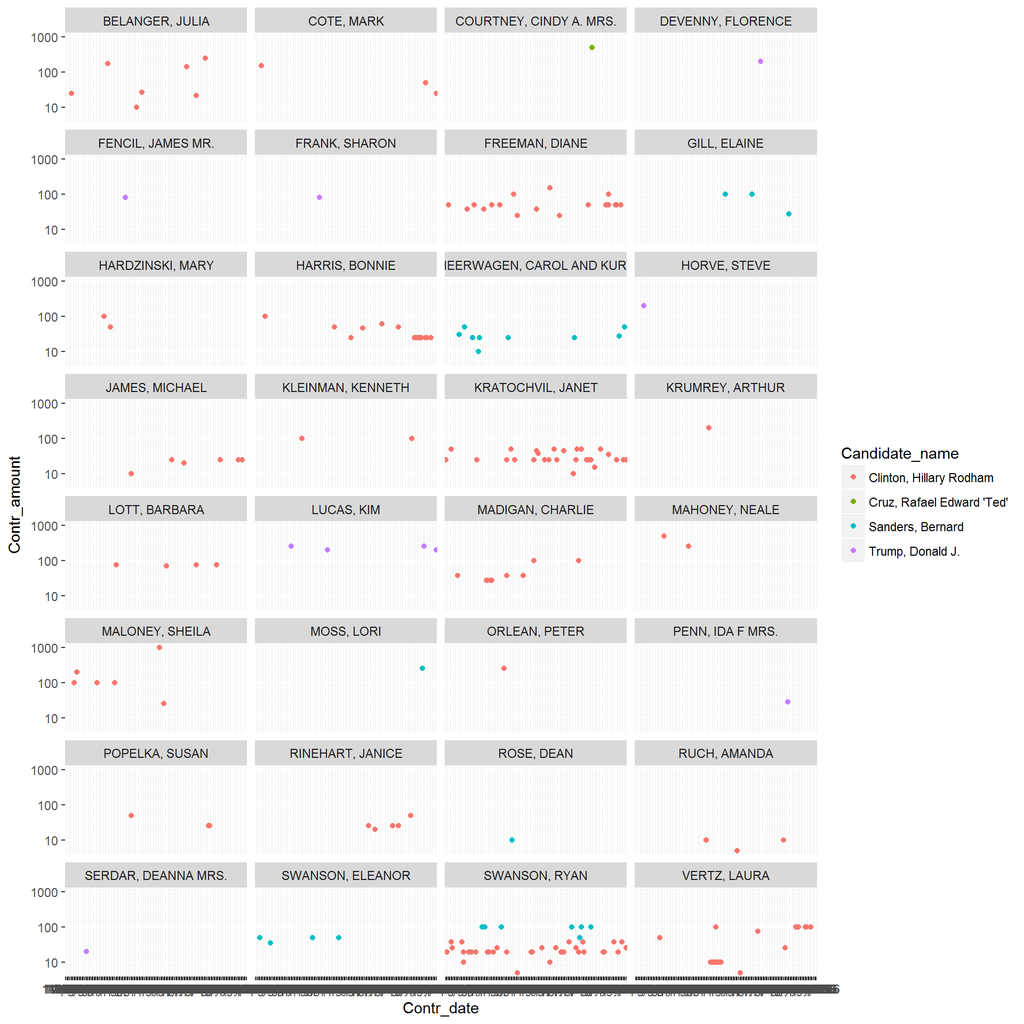

```r
set.seed(100)
sample.contri_names <- sample(levels(FC$Contr_Name), 32)

ggplot(data = subset(FC, Contr_Name %in% sample.contri_names),
       aes(x = Contr_date, y = Contr_amount, color = Candidate_name)) +
  facet_wrap(~Contr_Name, ncol = 4) +
  geom_point() +
  scale_y_log10()
```

It looks like the democrats, particularly Hillary supporters typically donate many times and Trump supporters donate only once. There is no obvious patterns with the date they donate. Interestsingly, one of the sample contributors donated to two candidates: both Clinton and Sanders.

# **Final Plots and Summary**

#### **Histogram of Contributions to Candidates of Different Parties**

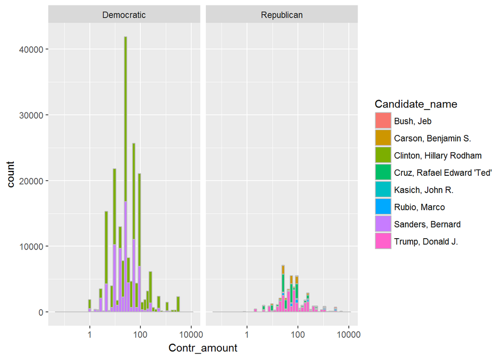

```r
ggplot(data = FC, aes(x = Contr_amount, fill = Candidate_name)) +
  geom_histogram(color = 'gray', bins = 50)  +
  facet_wrap(~Party, ncol = 2) +
  scale_x_log10()
```

#### **Total Contribution Received by Candidates VS Number of Unique Contributors by Candidates**

The number of unique contributors is likely a far better indicator of vote counts because many people doate more than once but everyone only gets one vote. Even though Hillary Clinton received significant larger contributions, her number of unique contributors is not that far off from Donald Trump’s number.

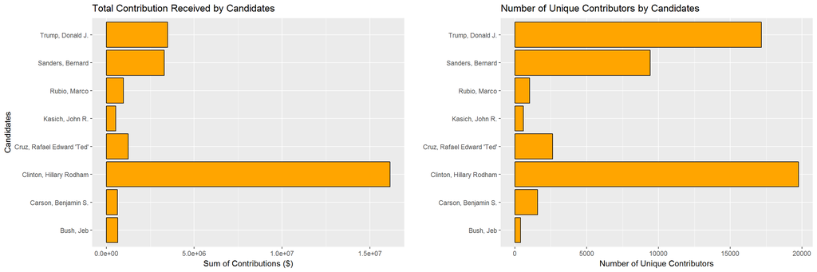

```r
f1 = ggplot(data = FC_selected, aes(Candidate_name, sum_amount)) +
  geom_col(fill = 'orange', color = 'black') +
  coord_flip() +
  ggtitle('Total Contribution Received by Candidates') +
  ylab('Sum of Contributions ($)') +
  xlab('Candidates')
f2 = ggplot(unique_contr, aes(Candidate_name, unique_contributors)) +
  geom_col(color = 'black', fill = 'orange') +
  coord_flip() +
  ggtitle('Number of Unique Contributors by Candidates') +
  ylab('Number of Unique Contributors') +
  xlab('')

grid.arrange(f1, f2, ncol = 2)
```

#### **Geographic Distribution of Contributors by Candidates**

These plots show some very interesting contributor patterns for different candidates. Notably, with the highest amount of total contributions (more than 4x of every other candidate), Clinton’s heat map is not filled as much as Trump’s. This indicates that more of Trump’s contributors are from rural area.

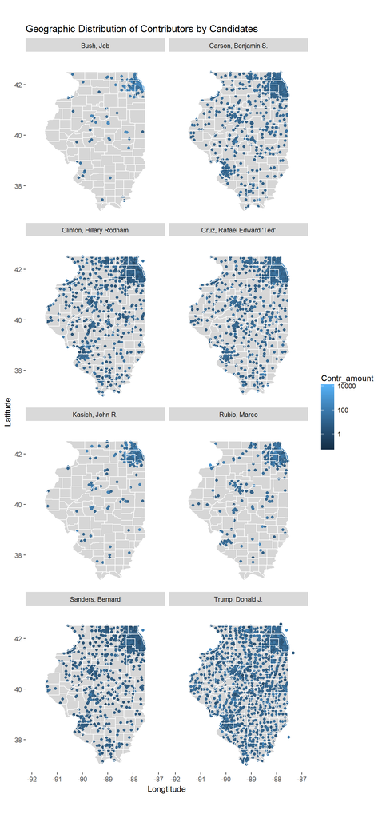

```r
ggplot(aes(x = lng, y = lat, color = Contr_amount), data = FC) +
  geom_point() +
  geom_polygon(data = illinois, aes(x = long, y = lat, group = group),
               color = 'gray', alpha = 0.2, inherit.aes = FALSE) +
  xlim(-92, -87) + ylim(37, 43)  +
  facet_wrap(~Candidate_name, ncol = 2) +
  coord_fixed(1) +
  geom_polygon(data = il_county, aes(x = long, y = lat, group = group),
                fill = NA, color = "white", inherit.aes = FALSE) +
  theme(panel.grid = element_blank(), panel.background = element_blank()) +
  scale_color_gradient(trans = 'log10') +
  ggtitle('Geographic Distribution of Contributors by Candidates') +
  xlab('Longtitude') +
  ylab('Latitude')
```

## **Reflections**

I realized how much more I could do at every step. It was a fascinating process!

Struggles:

- The limitation of the data presented the initial difficulty: I was not sure if I can come up with an extensive analysis with them. However, each step revealed something new and pointed me to different directions to go further, deeper.
- I had limited understanding of the electoral college system. If I did the process would have been much faster. I would know sooner how to frame my questions and where to look.
- I got sidetracked easily - wanting to create prettier plots, getting stuck at line of code and ending up looking at things way beyond the problem at hand etc.

Learning how to plot the data on the map was very interesting. I loved the process of making pretty graphs. I think visualization is where I want to put in more effort into in the future. I wanted to further categorize occupation and do more analysis based on that. Unfortunately that was out of my scope of knowledge at this point. I think taking just a few steps to examine the data for unique contributors can predict election results fairly effectively.